# l5_qualiii_es

Seminario de investigación

Semana 5: Entrevista y grupos de discusión

Sergi Martínez

smsoler@clio.uc3m.es | Horario de tutorías: martes de 10:00 a 13:00 (por correo electrónico)

**Recordatorio**: Horas de oficina - Proyecto de investigación

**Dónde estamos**:

- Sabemos cómo construir preguntas causales y teorías que nos permitan responderlas
- Dominamos la idea del contrafactual
- Nos hemos dado cuenta de algunos problemas que encontramos al intentar medir nuestros fenómenos de interés

**Hoy**

- Primera parte de la clase:
  - Recogida de datos cualitativos, en términos generales
  - Técnicas cualitativas basadas en hablar con y entre personas a través de entrevistas
- Segunda parte de la clase: Álvaro Canalejo-Molero presentará su trabajo sobre grupos de discusión
- Objetivo de la clase
  - Entender qué es una entrevista, ver ejemplos de ellas
  - Entender qué es un grupo de discusión y ver un proyecto que los utiliza

**Próxima sesión práctica sobre métodos cualitativos** (no necesariamente la próxima en el calendario):

- Límites éticos de la transparencia en la investigación cualitativa (entrevistas y grupos de discusión)
- Producir y analizar datos cualitativos (entrevistas y grupos de discusión)

**Mapeo de los métodos cualitativos**

## Diseño metodológico

**Metodología**: técnicas que usamos para recoger, analizar e interpretar datos

- Investigación cuantitativa: un examen numérico de la realidad basado en operacionalizaciones medidas. Fuentes de datos cuantitativos:
  - PolData y una [nota de investigación](https://www.researchgate.net/publication/385134581_Data_and_data_sets) que la contextualiza
  - Investigación cualitativa: *`examen no numérico de la realidad llevado a cabo normalmente mediante el uso de la descripción verbal’* Berdhal y Archer (2015)

Objetivo de usar la investigación cualitativa: **obtener una imagen holística sobre los fenómenos de interés**

- Cuál es el significado o cómo se entiende algo (validación de lo normativo)
- Cuáles son los procesos, las secuencias de eventos y los actores involucrados (preguntas de procedimiento)
- Cuáles son los detalles contextuales

Nótese que esto puede ser útil para

- Enfoques inductivos: esfuerzos de construcción de teoría
- Enfoques deductivos: periodo de observación previo a la teorización, test e interpretación posterior al contraste

Cómo: a través del **estudio detallado de un número reducido de observaciones**, de una forma

- (Aparentemente) menos estructurada (pese a tener un método) que la cuantitativa
- Basada en temas, más que en variables

## Dimensiones críticas

Como en la investigación cuantitativa:

| **Muestreo** | **Método de recogida de datos** | **Análisis e interpretación de datos** |
| --- | --- | --- |
| Muestreo aleatorio | Observación participante | Análisis temático |
| Muestreo intencional | Observación no participante | Análisis de contenido |
| Muestreo teórico | *Entrevistas estructuradas* | Análisis del discurso |
| Muestreo en bola de nieve | *Entrevistas semiestructuradas* | Análisis narrativo |
| Selección de casos extremos o desviados | *Entrevistas no estructuradas* | Rastreo de procesos (process tracing) |
| Diseño de casos más similares o más diferentes | *Grupos de discusión* | Codificación de teoría fundamentada |
| Selección de casos típicos | Revisión documental o de archivo | Tipológico o de coincidencia de patrones |

Las respuestas a estos dilemas vendrán determinadas por el tipo de pregunta y los datos que necesitemos para *complementar* o conciliar los datos cuantitativos

## ¿Qué casos observamos? ¿A quién muestreamos?

Estrategias de muestreo no probabilístico para maximizar la comprensión a costa de la *representatividad* de las sociedades (que proporciona el muestreo aleatorio)

- Muestreo intencional o por juicio: los investigadores observan los casos y los seleccionan para maximizar la cantidad de información
- Muestreo de casos típicos frente a casos extremos
- Muestreo en bola de nieve o de red: identificar unos pocos casos clave y luego obtener referencias a otros [Consultar con los comités de ética]
- Muestreo por cuotas: muestreo intencional para identificar un número mínimo de participantes o entrevistados (objetivo) por estrato (celda) para lograr cierta representatividad dentro de un grupo

## Tipos de datos cualitativos

|  | Personas | Texto |
| --- | --- | --- |
| Entorno de investigación | Entrevistas Grupos de discusión | Diarios y cuadernos solicitados Cuestionarios abiertos Viñetas y ejercicios Q sort |
| “Mundo real” | Investigación observacional (etnografía) | Análisis del discurso Revisión documental |

- Hoy nos centraremos en medidas intrusivas: entrevistas y grupos de discusión
- El estudio de caso y el rastreo de procesos combinan todos estos tipos de métodos cualitativos para recrear una cronología de eventos y grupos, y evaluar cuándo, quién, cómo y por qué las causas están vinculadas a los efectos

## Disparó al pianista (2023)

[video not shown]

## El año del descubrimiento

[figure not shown]

**Entrevistas**

## Entrevista: definición y frecuecia de uso

Técnica de investigación basada en una conversación profesional, guiada y con un propósito específico, cuyo objetivo es comprender en profundidad las perspectivas, motivaciones, valores, ideologías y experiencias de actores políticos o sociales

- Las entrevistas están presentes en los hallazgos más conocidos de la ciencia política:
  - *Who Governs* de Dahl
  - *Weapons of the Weak* de Scott
  - El artículo de Heinze sobre elecciones directas y el poder de las élites en la India [construcción y contraste de teoría]
  - El artículo de Cremaschi, De Vries y Bariletto sobre la Xyllela en Puglia [construcción y contraste de teoría]: *“We develop a set of deductive expectations and inductively build a theory to explain…”*

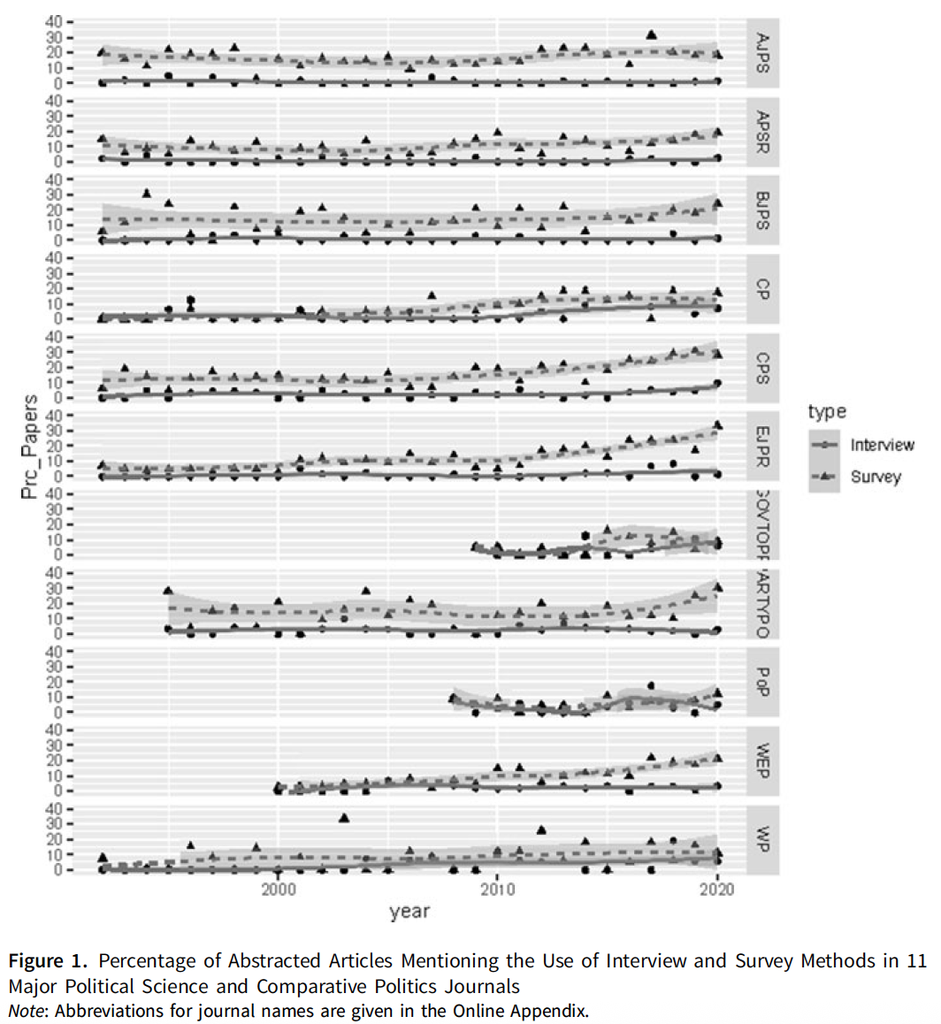

## Por qué queremos hacer una entrevista

Obtener información sobre

- Qué hay realmente en el proceso [significado]
- Cómo ocurrió un proceso [cómo afectó X al Y]
- Por qué ocurrió un proceso [qué llevó a la decisión, cuál fue la secuencia de eventos]
- El contexto en el que ocurrió el proceso [actores, detalles contextuales]

**Investigación exploratoria**

- Qué está pasando
- ¿Qué sigue? ¿Quién sabe más? ¿Qué es más interesante?

Mosley (2013) sostiene que los estudiantes de posgrado deberían comenzar su trabajo de campo *‘simplemente hablando con la gente’*

## Mi preocupación con eso de `simplemente ve y habla con la gente’

[video not shown]

Bromas aparte, debemos hablar con personas antes del trabajo de campo (en remoto, o con contactos que tengamos) para

- Planificarlo adecuadamente
- Someter dicha planificación para revisión ética (IRB, CEI en UC3M)
  - Para evitar riesgos al equipo de investigación
  - Para minimizar el impacto en los sujetos de la investigación

## Antes, durante y después del trabajo de campo

Una vez que tienes una idea sobre el trabajo de campo, una población objetivo, una lista completa de preguntas y un plan para analizar los datos, puedes presentar una **solicitud al Comité de Ética o Institutional Review Board**.

Investigación previa a la entrevista:

- Guion de la entrevista: lista de preguntas o temas que el entrevistador necesita preguntar. La entrevista comenzará con preguntas factuales sencillas y terminará con una nota *positiva*
- Antecedentes del entrevistado: contexto, terminología aceptada

Durante la entrevista:

- Registrar la información: notas, dispositivo de grabación (teléfono)
- Gestionar y adaptar la entrevista según el tiempo y el estado de ánimo–rapport

Después de la entrevista

- Transcribir toda la entrevista (ejem, esto..) [dependiendo de la información, el entrevistado, etc. puedes usar IA para esta transcripción]
- Adaptar las notas escritas
- Escribir un breve informe o memo sobre esta entrevista

## Tres preguntas que hacerse antes de una entrevista

**¿Qué grado de estructura?**

- Estructurada
- Semiestructurada
- No estructurada

**¿A quién y cómo?**

- Élite o no élite
- Presencial, telefónica u online

**¿Cuántas personas a la vez?**

- Individual (uno a uno)
- Entrevistas grupales
- Grupos de discusión

La triangulación, como discutiremos más adelante, sería lo ideal

## ¿A quién? Muestreo [con propósito]

- Si se construye teoría, depende de sobre quién estemos teorizando
- Si se contrasta teoría, necesitamos observar cómo reacciona nuestra población de interés
- Si se está refinando, también podemos acudir a expertos y élites
1. Ciudadanos comunes
2. Entrevistas de élite:
- Personas en una posición de poder dentro del sector
- Personas con conocimiento específico sobre nuestro tema o caso de análisis
3. Poblaciones difíciles de alcanzar
- Ciertos estratos afectados por nuestro fenómeno de interés pueden ser difíciles de contactar

## 3 tipos: Entrevistas estructuradas

- Comparabilidad. Mismas preguntas y orden, $\nabla$ reduce el sesgo
- Preguntas de investigación sobre comparaciones sistemáticas entre muchos encuestados
- Más cercana al trabajo de encuestas que a la indagación cualitativa abierta, y a menudo se usa junto con medidas cuantitativas
- Más utilizada en investigación deductiva, donde contrastamos nuestras teorías `cerradas’

[interactive chart not shown]

## Ejemplo: Balcells (2012)

[interactive chart not shown]

## 3 tipos: Entrevistas semiestructuradas

Más flexible: conversación real, manejo individualizado

- Lista de comprobación de temas, no un guion fijo de preguntas
- Permite al entrevistador profundizar, hacer seguimiento y reordenar a medida que avanza la conversación
- Produce datos comparables entre entrevistas sin dejar de capturar matices

[interactive chart not shown]

## Ejemplo de Estamos Listas

[figure not shown]

[interactive chart not shown]

## 3 tipos: Entrevistas no estructuradas

Solo temas, dejando que la conversación fluya libremente en distintas direcciones

- Muy flexible, abierta a información inesperada. Perfecta para trabajo exploratorio
- El orden de las preguntas importa menos
- Riesgo: puede quedar fuera información importante

**Utilizada en**

- Scott, J. C. (1985). *Weapons of the Weak*. Yale University Press. Conversaciones abiertas y repetidas con aldeanos en “Sedaka”, Malasia
- Stepan, A. C. (1971). *The Military in Politics*. Princeton University Press. Conversaciones informales y formales con cientos de oficiales brasileños
- Dahl, R. A. (1974). *Who Governs*. Yale University Press. Casi 50 entrevistas sobre política municipal en New Haven

## Eligiendo entre ambas

- Las entrevistas no estructuradas funcionan mejor en etapas tempranas y exploratorias de la investigación [observación para construir teoría], o cuando el objetivo es entender cómo alguien da sentido a su mundo, en sus propios términos
- Las entrevistas repetidas con las mismas personas, sean semiestructuradas o no, ayudan a generar cercanía y más confianza. Goodwin (2011) volvió a entrevistar a activistas del British National Party, incluido su líder, en distintos momentos para triangular

Ambos tipos se juzgan con el mismo estándar. El investigador debe ser transparente sobre cómo se construyeron las preguntas y cómo se analizaron las respuestas

## Población objetivo: a quién estamos entrevistando

**Entrevistas de élite**

- Políticos, burócratas, líderes y cargos de partido, élites empresariales o profesionales
- Normalmente un número reducido de entrevistas con personas que poseen un conocimiento específico, a menudo único
- El acceso es el reto. Las élites están ocupadas, a menudo protegidas por guardianes de acceso, y tienen poco incentivo para ayudar a un investigador

**Entrevistas a ciudadanos no élite**

- Miembros del público, activistas, votantes, militantes de partido, personas afectadas por una política
- Permiten alcanzar números más grandes, lo que favorece datos más densos y saturados
- El reto es el muestreo, ya que un conjunto no representativo de encuestados puede sesgar la validez

## Entrevistas de élite: acceso y cercanía

El acceso puede fallar por razones que no tienen nada que ver con las preguntas formuladas.

- Ellinas describe haber perdido el acceso a todo un partido tras una sola pregunta que tocó un asunto interno sensible, y haber perdido el acceso a un evento nacional después de que un periodista informara mal sobre su presencia
- Las preguntas sensibles es mejor dejarlas para más adelante en la entrevista, una vez que se ha generado algo de confianza

Las llamadas y los correos en frío tienden a fallar.

- Ellinas recurrió a asistir a eventos públicos de partidos y a intermediarios, y nunca inició el contacto con una llamada en frío

Cómo se enmarca la investigación cambia qué puertas se abren.

- Ellinas: decir “estudio partidos nacionalistas” abre más puertas que “estudio extremistas de derecha”, aunque ambas frases describan el mismo proyecto

## Ejemplo de mi artículo sobre CITREP

En mi experiencia, solo una pequeña fracción de las personas a las que contactamos (10%) respondió a nuestro primer mensaje [artículo de CITREP sobre Colombia]

[interactive chart not shown]

## Entrevistas a elites: otro ejemplo

Ellinas (2023) realizó 58 entrevistas a líderes y cargos de la extrema derecha en cinco países europeos para estudiar a una población difícil de contactar (y estigmatizada)

- **Triangulación de datos**: Contrastó las afirmaciones de las entrevistas con documentos y comunicación oficial del partido y archivos de prensa
- **Triangulación posicional**: Entrevistó tanto a cargos de la extrema derecha como a antifascistas locales sobre los mismos eventos
- **Triangulación geográfica**: Repartió las entrevistas entre varias sedes urbanas y rurales en lugar de concentrarse en una sola capital
- **Triangulación temporal**: Repitió entrevistas con los mismos activistas a lo largo del tiempo, lo que permitió confirmar y contrastar info, así como profundizar en temas sensibles

¿Cuándo parar? Cuando se llega al punto absoluto de saturación.

## Cuanti-Cuali: It’s a match!

Ellinas estudia el estigma entre activistas de la extrema derecha a través de entrevistas, notas de campo y observación. Ammassari (2023) plantea una pregunta relacionada con un método diferente

Ammassari, S. (2023) Feelings of stigmatisation among populist radical right party members. *European Journal of Political Research*, 62(3), 723 to 741

**Ellinas, cualitativo**

- Notas de campo y entrevistas semiestructuradas con líderes y cargos
- Lxs activistas de extrama derecha mencionan sentirse discriminadxs entre las razones que para *abandonar*. También surge de la profundidad de la estructura de red en cada lugar
- Pros: Profundidad sobre un número reducido de casos, prestando atención al proceso

**Ammassari, cuantitativo**

- Un instrumento de encuesta que mide directamente los sentimientos de estigmatización, en una muestra amplia de militantes de partido

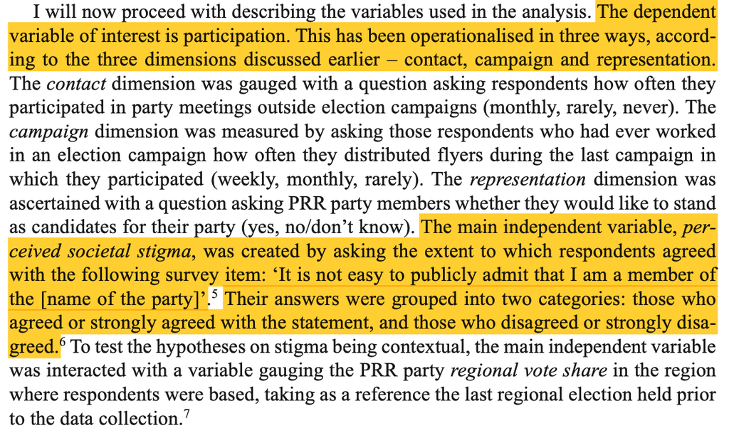

Ningún enfoque sustituye al otro. Las entrevistas muestran cómo personas concretas viven y hablan del estigma, mientras que la encuesta muestra hasta qué punto se comparte ese sentimiento de estigma y qué lo predice